# Labor Market Analysis

## Task 2:

Compute and examine descriptive statistics including the minimum, maximum, mean, and median for quantitative variables of interest

### Total person’s earnings

|  | ss16ppr (N = 5,194) |
| --- | --- |
| Minimum | 10000.00 |
| Maximum | 125000.00 |
| Median | 24000.00 |
| Mean | 29278.84 |

### Age

[output not shown]

### Hours worked

|  | ss16ppr (N = 5,194) |
| --- | --- |
| Minimum | 35.00000 |
| Maximum | 99.00000 |
| Median | 40.00000 |
| Mean | 41.21544 |

### Ethicity: Hispanic

| RACHISP | Count |
| --- | --- |
| No | 5104 |
| Yes | 90 |

### Race: White

In Puerto Rico, the majority of people identify themselves as white. Minority races including American Indian, Alaska Native, Asian, Native Hawaiian and Other Pacific Islander can be eliminated.

| RACWHT | Count |
| --- | --- |
| No | 1401 |
| Yes | 3793 |

### Race: Black

| RACBLK | Count |
| --- | --- |
| No | 4417 |
| Yes | 777 |

### Race: Other

| RACOTHER | Count |
| --- | --- |
| No | 4381 |
| Yes | 813 |

### Marital status

| MAR | Count |
| --- | --- |
| Married | 2580 |
| Widowed | 65 |
| Divorced | 944 |
| Separated | 105 |
| Never married | 1500 |

| MAR1 | Count |
| --- | --- |
| No | 2614 |
| Yes | 2580 |

# Educational attainment

| SCHL | Count |
| --- | --- |
| High school diploma | 1148 |
| Some college | 791 |
| Associate’s degree | 818 |
| Bachelor’s degree | 1726 |
| Master’s degree | 505 |
| Professional degree | 113 |
| Doctorate degree | 93 |

## Sex

| SEX | Count |
| --- | --- |
| Male | 2627 |
| Female | 2567 |

## Task 3:

Generate and examine histograms for quantitative variables of interest

### Total person’s earnings

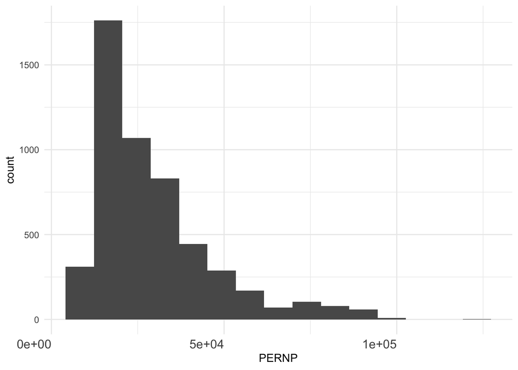

### Age

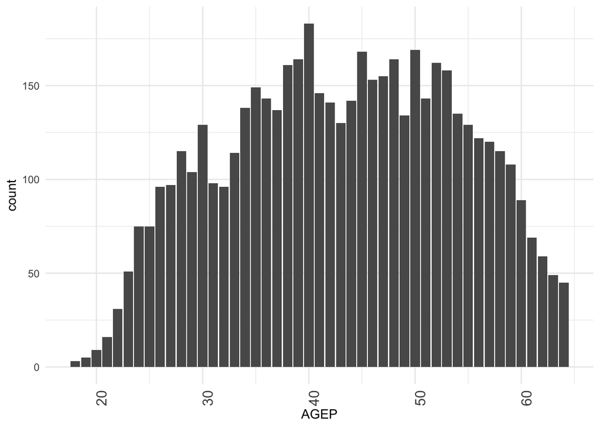

### Hours worked

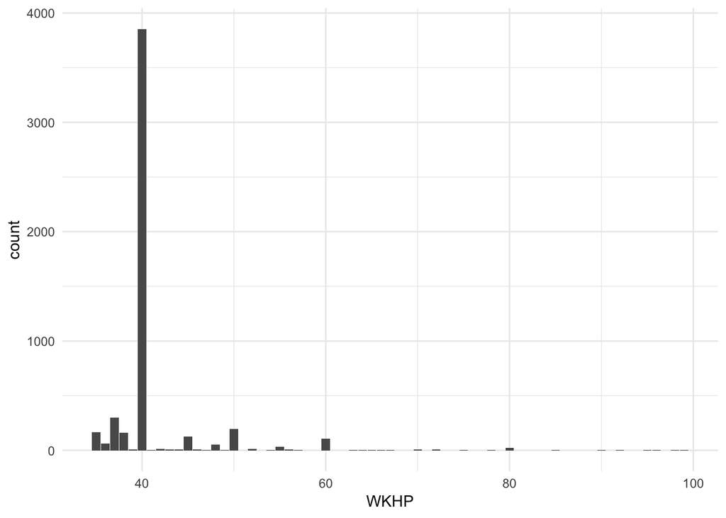

## Task 4:

Generate and examine bar charts/graphs for qualitative variables of interest

### Race

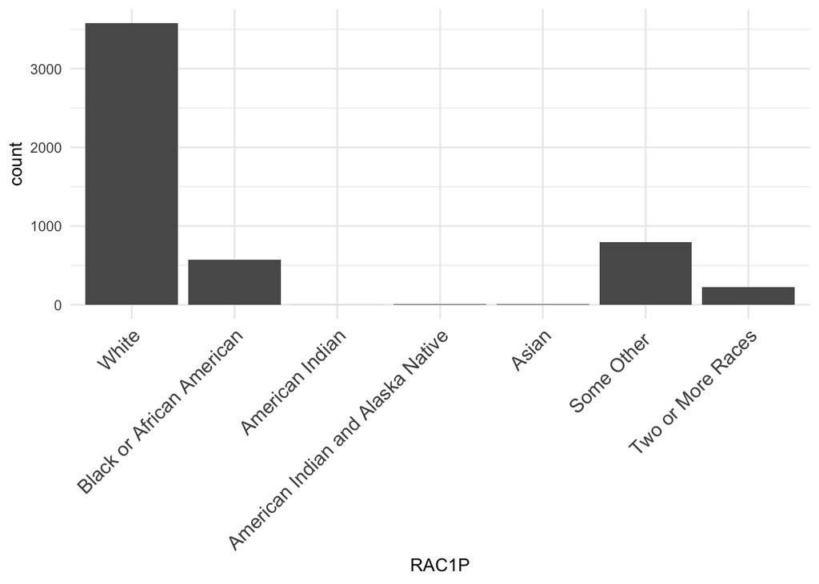

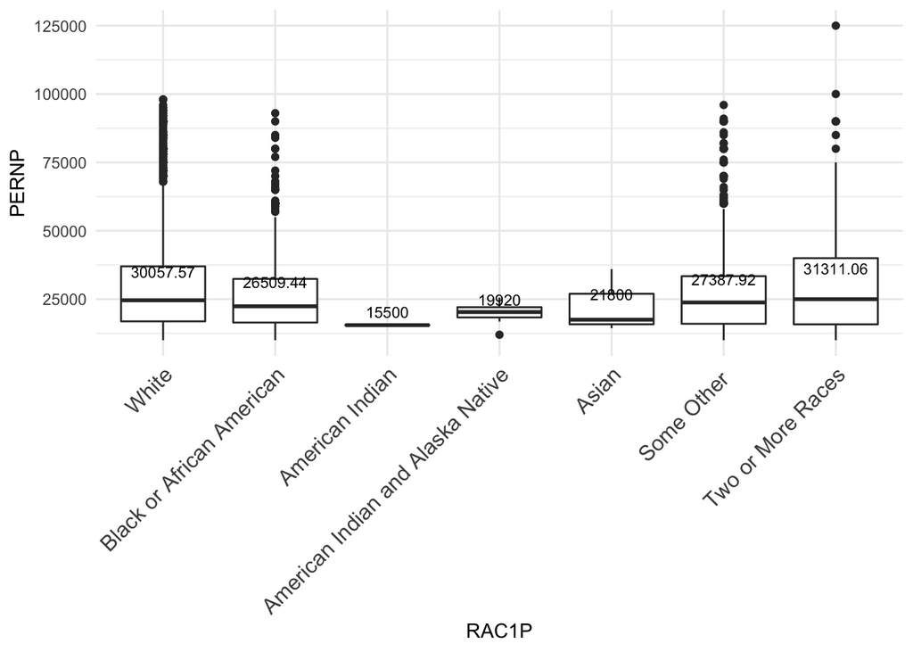

### White

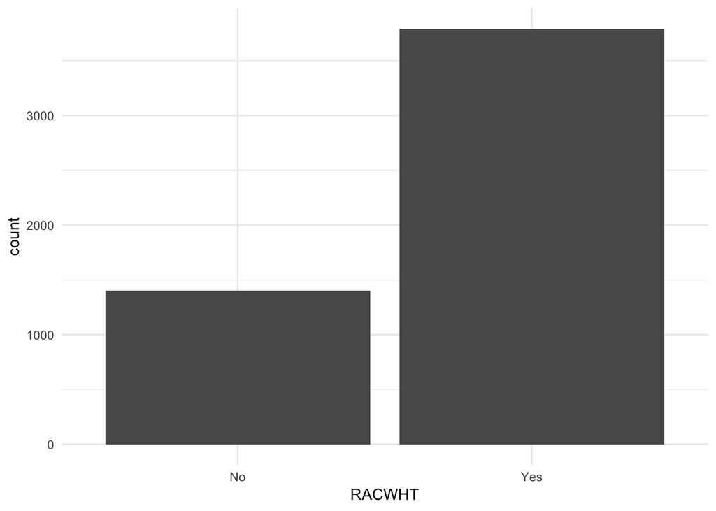

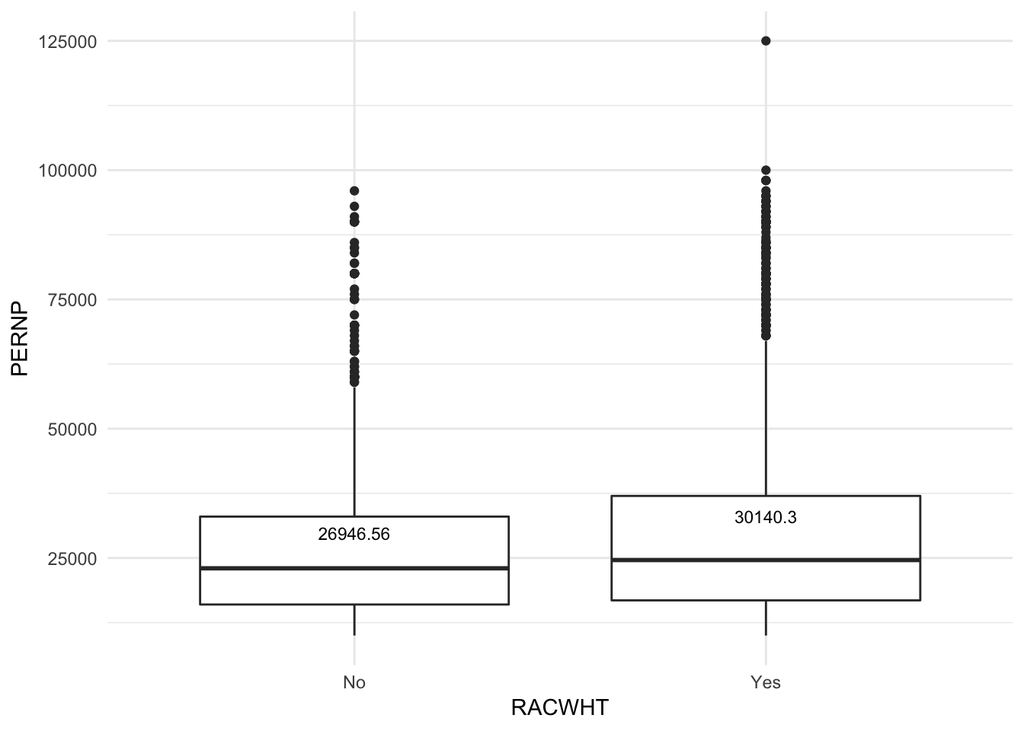

### Black

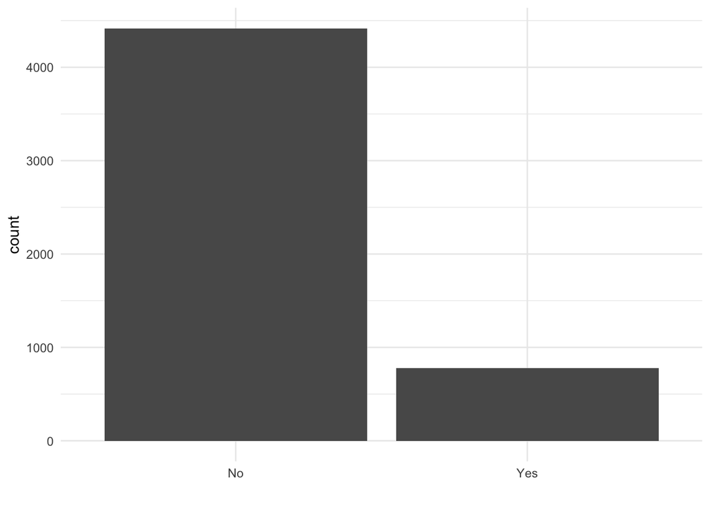

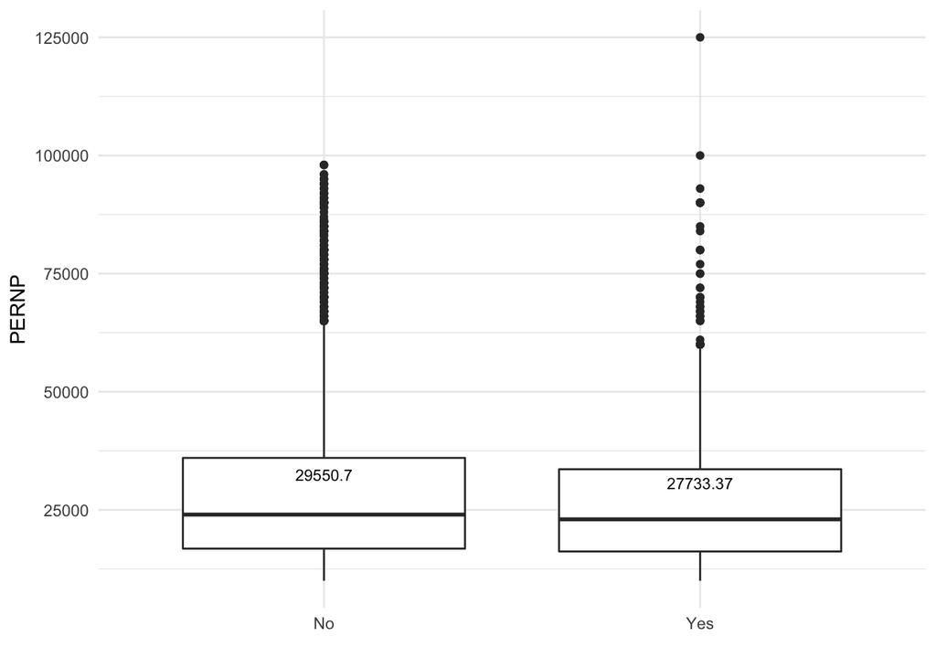

### Race: Other

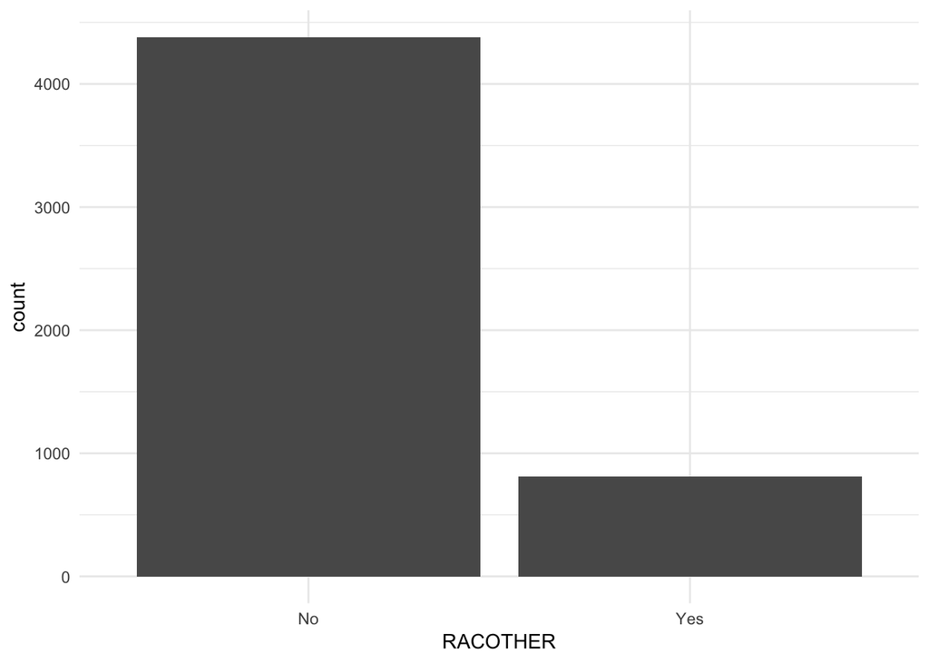

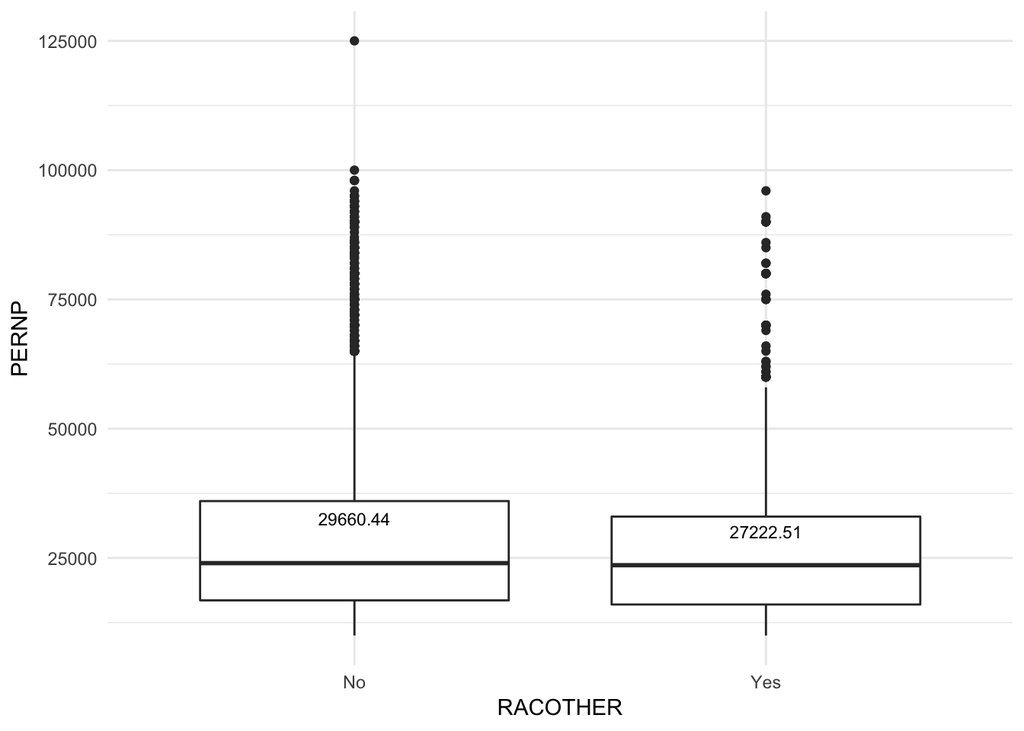

### Marital Status

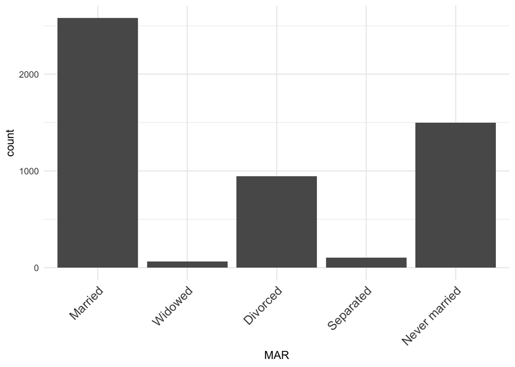

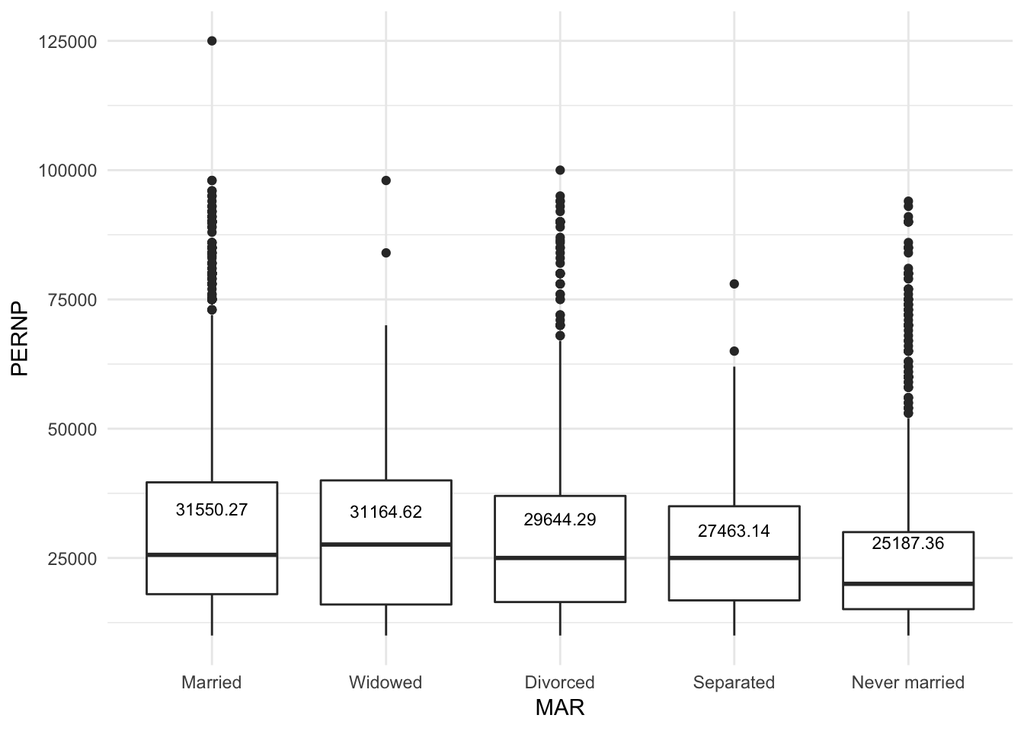

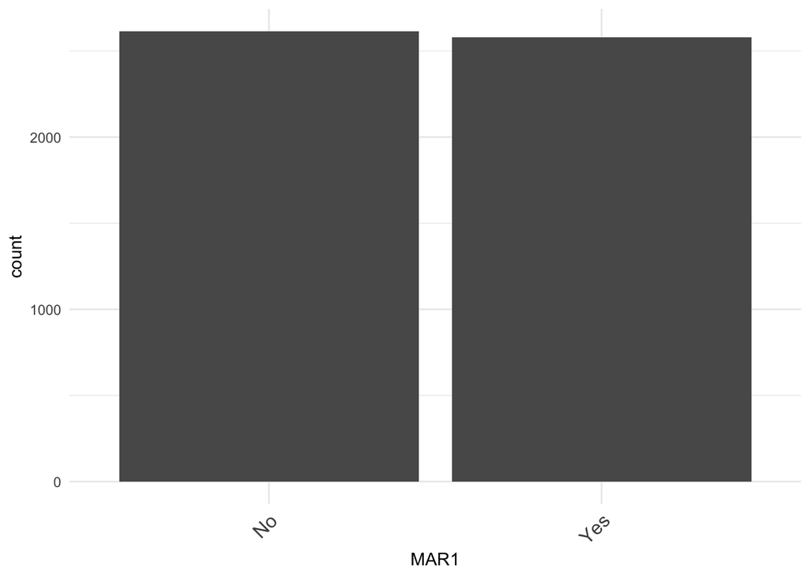

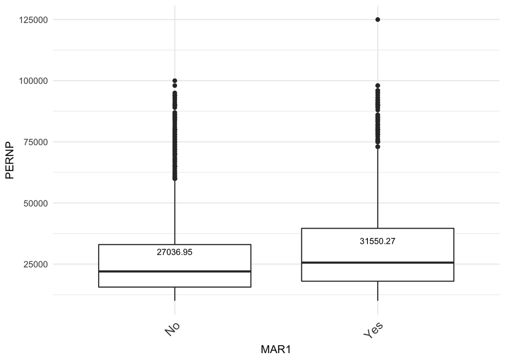

## Educational attainment

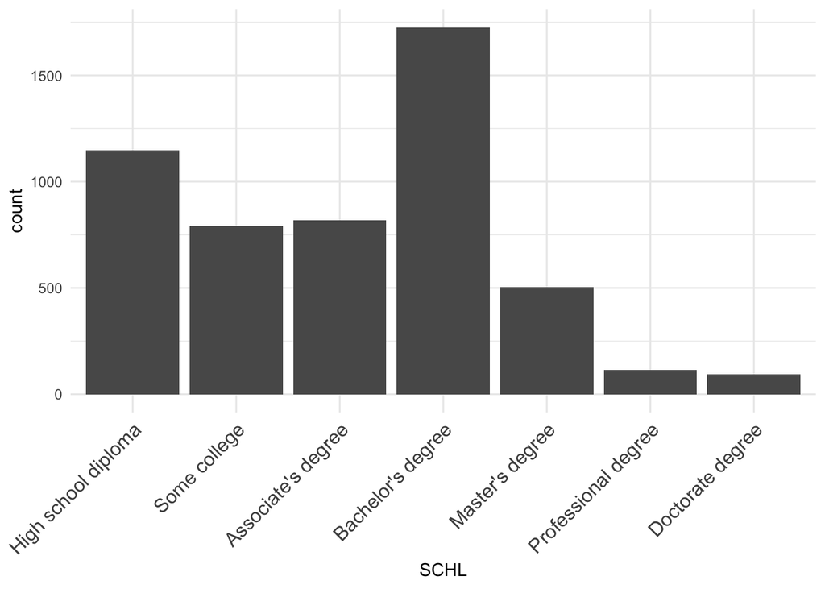

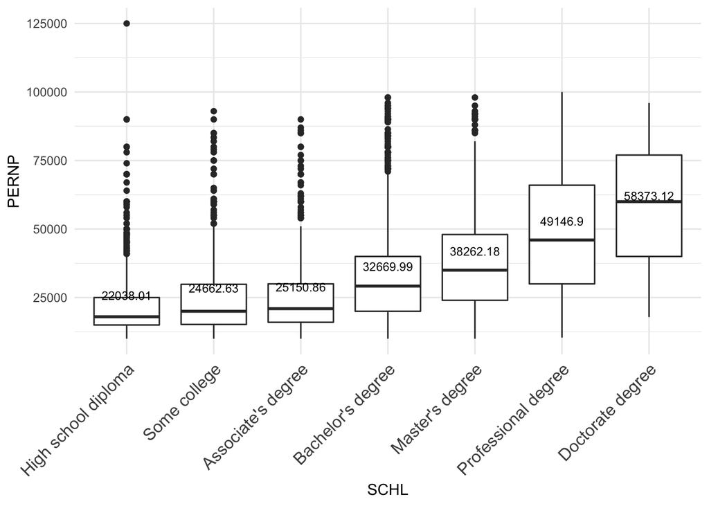

## Sex

Gender is nearly equalized in Puerto Rico

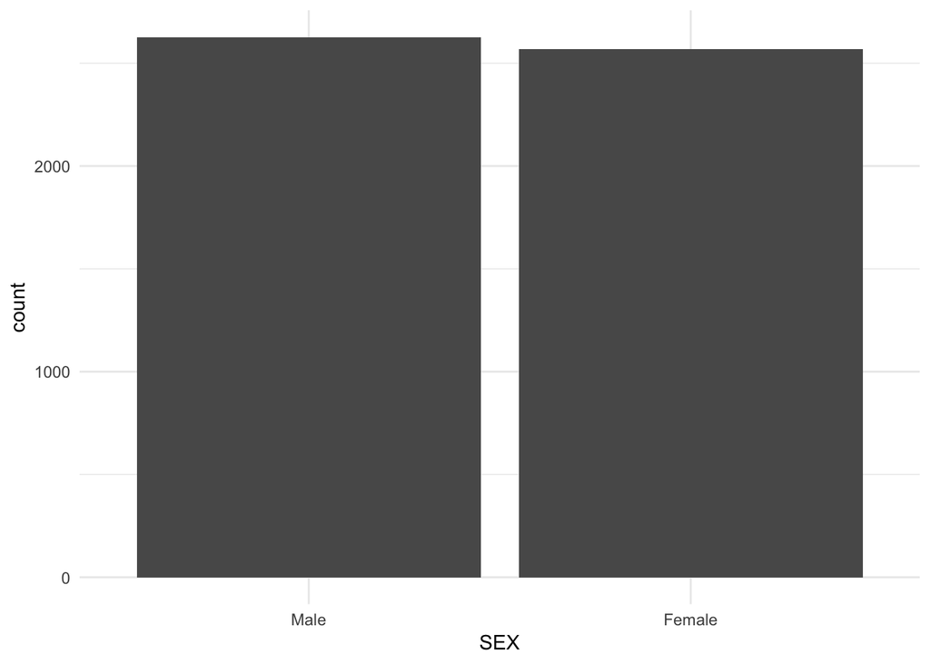

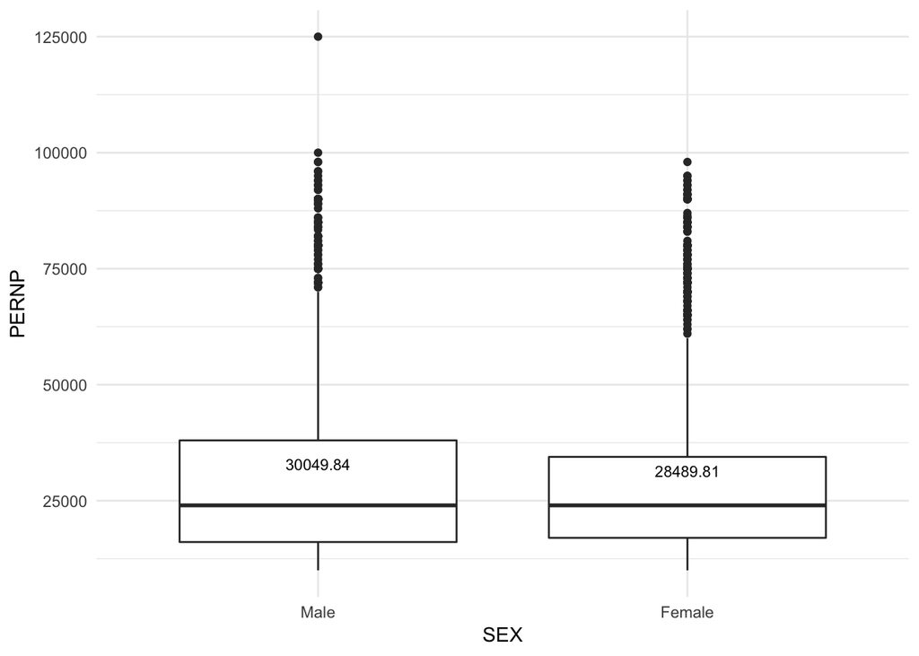